# Demo 1: Análisis de discursos de campaña en Twitter: Elecciones Presidenciales 2021 en Chile

Ciencias Sociales Computacionales 2021, Facultad de Ciencias Sociales de la Universidad de Chile

Camila Pávez, Maru Meléndez, Carolina Carrillo y Karina Moreno

04/11/2021

# 1 Introducción

Podemos rastrear el uso de redes sociales en campañas políticas en Chile hasta la elección presidencial de 2009-2010, la primera luego de la exitosa experiencia documentada a nivel mundial de la campaña por redes sociales desplegada por el equipo de campaña de Barack Obama (Cárdenas, Ballesteros y Jara, 2017; González-Bustamante y Muñoz, 2012). Tras estas elecciones, las redes sociales han estado presentes en prácticamente todas las campañas políticas chilenas, abriéndose paso principalmente en las candidaturas más jóvenes, siendo destacable el uso de redes sociales en las campañas de la coalición del Frente Amplio (MediaInteractive y TrenDigital, 2017; Huneeus, 2021).

Se ha propuesto la importancia de analizar el rol de las campañas por redes sociales en contextos de desconfianza hacia las élites políticas, los medios tradicionales y el conocimiento de los expertos, pudiendo ser aplicable al contexto político chileno (Heiss, 2021). Ya se ha demostrado que en casos como el Brexit (Marshall y Drieschova, 2018), estos factores fueron importantes en la elección de las personas a depender en fuentes alternativas de información.

En esta línea, a nivel nacional se ha visto la tendencia del aumento del consumo y confianza en redes sociales, en desmedro de los medios comunicacionales tradicionales. La última encuesta CEP, realizada en diciembre del año 2019, muestra que un 28% de los encuestados manifestó tener mucha o bastante confianza en las redes sociales, en promedio superando la confianza en los medios tradicionales, como radio, periódicos y televisión. Asimismo, un 13% manifestó siempre seguir temas políticos a través de RRSS, y un 30% manifestó hacerlo a veces. Este porcentaje ha ido creciendo significativamente con los años, duplicándose desde la CEP Agosto 2015 (Centro de Estudios Públicos, 2020).

En tanto, el uso de tecnologías de la información y redes sociales también ha crecido precipitadamente. Distintos estudios afirman que Chile es probablemente uno de los países con mayor tasa de penetración de Internet en América Latina (Huawei, 2020), y los indicadores de conectividad no han dejado de crecer. En los últimos seis años, la conexión a internet móvil se ha duplicado en el país, llegando en diciembre de 2020 a una penetración total de aproximadamente 106 conexiones a red móvil por cada 100 habitantes (Subsecretaría de Telecomunicaciones de Chile [SUBTEL], 2020). Además, a esto se le debe sumar la aceleración de dichas transformaciones como fruto de las medidas sanitarias por COVID-19, habiéndose registrado en el último año un aumento de usuarios de internet y de redes sociales (Rosgaby, 2021).

A partir de lo presentado, se puede extraer la importancia del análisis de campaña en redes sociales, especialmente en Twitter. Ahora bien, este estudio contempla el análisis de Tweets producidos no sólo de los candidatos y sus comandos de campaña, sino que se propone el estudio de la campaña en redes sociales como una construcción plural de discursos. Al respecto, se ha sugerido que la participación interactiva de los electores, naturalmente promovida por las plataformas de redes sociales, constituye un mecanismo para aumentar el compromiso político y diálogo entre los usuarios (Bor, 2014). Así, se quiebra el modelo de consumo político de los medios de masas (Tironi y Cavallo, 2007), y la relación de los ciudadanos con las figuras políticas en redes sociales puede trascender las lógicas verticales de información y consumo, permitiendo horizontalidad en la creación de los contenidos políticos, su distribución en línea y la interacción virtual activa (González-Bustamante y Muñoz, 2012).

Más aún, el presente estudio propone el análisis de Tweets publicados entre el 15 y 20 de noviembre, la última semana antes de la Primera Vuelta Presidencial. De esta forma coincidiendo con el fin del periodo de campaña oficial, el 18 de noviembre, luego del cual los candidatos y sus comandos deberán abandonar la campaña, pudiendo tomar un rol predominante las redes sociales.

## 1.1 Pregunta de investigación

A partir de lo presentado anteriormente, y considerando la falta de investigación actual respecto a la temática, es de interés explorar ¿cómo se despliegan los discursos de campaña en redes sociales, en Tweets que mencionan a les candidates presidenciales en Chile entre el 15 y el 20 de noviembre de 2021?

En esta línea, se propone analizar con fines exploratorios: *a.* La intensidad de campaña por Twitter en mención de cada candidate. Explorar la cantidad de tweets que mencionan a cada candidate. *b.* Las temáticas de campaña por Twitter en mención de cada candidate. Extrayendo el contenido semántico más frecuente de los Tweets seleccionados, analizar descriptivamente las temáticas presentes en los discursos de campaña. *c.* Las intenciones de campaña por Twitter en mención de cada candidate, a partir de las principales temáticas extraídas.

# 2 Metodología

Los datos se extrajeron desde la API de Twitter, utilizando para su recolección el paquete *rtweet 0.7.0* en R. Se recolectaron tweets que contengan menciones directas a les siguientes candidates durante las semanas de propaganda electoral: Gabriel Boric (“@gabrielboric”, “Gabriel Boric”, ”Boric”, “boric”), José Antonio Kast (“@joseantoniokast”, “José Antonio Kast”, “J.A.K.”, “JAK”, “Kast”), Yasna Provoste (“@provosteyasnal”, “Yasna Provoste”, “Provoste”, “provoste”), Sebastián Sichel (“@sebastiansichel”,”Sebastián Sichel”, “Sichel”, “sichel”), Marco Enríquez-Ominami (“@marcoporchile”, “Marco Enríquez Ominami”, “meo”, ”MEO”, “ME-O”), Franco Parisi (“@parisi_oficial”, “Franco Parisi”, “Parisi”, “parisi”) y Eduardo Artés (“@artes_oficial”, “Eduardo Artés”, “Artés”, “artés”). El análisis inicial de estos tweets se basa en la elaboración de gráficos de barras que exponen la cantidad de tweets por candidate, y nubes de palabras donde se visualizan lo que más se repite en los tweets con menciones directas hacia cada une.

# 3 Análisis primarios

```r
# 1. Cargar librerias
# install.packages("pacman")
library(pacman)
p_load(rtweet, tidyverse, wordcloud, ggplot2, RColorBrewer, stopwords, wordcloud, tm)

# 2.a. Se incluyen las credenciales personales de API Twitter
# consumer_key <- 'XXX'
# consumer_secret <- 'XXX'
# access_token <- 'XXX'
# access_secret <- 'XXX'

# 2.b. Se autentifica vía web browser
# token <- create_token(
#          app = "Campaign_Chile_2021",
#          consumer_key = consumer_key,
#          consumer_secret = consumer_secret,
#          access_token = access_token,
#          access_secret = access_secret)
# get_token()
```

```r
# 3. Descarga primera semana
# 3.a. Menciones candidato Boric
# menciones_boric_1 <- search_tweets("@gabrielboric", retryonratelimit = TRUE)
# menciones_boric_2<- search_tweets("Gabriel Boric", retryonratelimit = TRUE)
# menciones_boric_3<- search_tweets("Boric", retryonratelimit = TRUE)
# menciones_boric_4<- search_tweets("boric", retryonratelimit = TRUE)

#3.b. Menciones candidato Kast
# menciones_kast_1 <- search_tweets("@joseantoniokast", retryonratelimit = TRUE)
# menciones_kast_2<- search_tweets("José Antonio Kast", retryonratelimit = TRUE)
# menciones_kast_3<- search_tweets("J.A.K", retryonratelimit = TRUE)
# menciones_kast_4<- search_tweets("JAK", retryonratelimit = TRUE)
# menciones_kast_5<- search_tweets("Kast", retryonratelimit = TRUE)

#3.c. Menciones candidata Provoste
# menciones_provoste_1 <- search_tweets("@provosteyasnal", retryonratelimit = TRUE)
# menciones_provoste_2 <- search_tweets("Yasna Provoste", retryonratelimit = TRUE)
# menciones_provoste_3<- search_tweets("Provoste", retryonratelimit = TRUE)
# menciones_provoste_4<- search_tweets("provoste", retryonratelimit = TRUE)

#3.d. Menciones candidato Sichel
# menciones_sichel_1 <- search_tweets("@sebastiansichel", retryonratelimit = TRUE)
# menciones_sichel_2 <- search_tweets("Sebastián Sichel", retryonratelimit = TRUE)
# menciones_sichel_3 <- search_tweets("Sichel", retryonratelimit = TRUE)
# menciones_sichel_4<- search_tweets("sichel", retryonratelimit = TRUE)

#3.e. Menciones candidato Enríquez-Ominami
# menciones_meo_1 <- search_tweets("@marcoporchile", retryonratelimit = TRUE)
# menciones_meo_2<- search_tweets("Marco Enríquez Ominami", retryonratelimit = TRUE)
# menciones_meo_3<- search_tweets("meo", retryonratelimit = TRUE)
# menciones_meo_4<- search_tweets("MEO", retryonratelimit = TRUE)
# menciones_meo_5<- search_tweets("ME-O", retryonratelimit = TRUE)

#3.f. Menciones candidato Parisi
# menciones_parisi_1 <- search_tweets("@parisi_oficial", retryonratelimit = TRUE)
# menciones_parisi_2<- search_tweets("Franco Parisi", retryonratelimit = TRUE)
# menciones_parisi_3<- search_tweets("Parisi", retryonratelimit = TRUE)
# menciones_parisi_4<- search_tweets("parisi", retryonratelimit = TRUE)

#3.g. Menciones candidato Artés
# menciones_artes_1 <- search_tweets("@artes_oficial", retryonratelimit = TRUE)
# menciones_artes_2<- search_tweets("Eduardo Artés", retryonratelimit = TRUE)
# menciones_artes_3<- search_tweets("Artés", retryonratelimit = TRUE)
# menciones_artes_4<- search_tweets("artés", retryonratelimit = TRUE)
```

```r
# 4.a. Arrange data frame candidato Boric
# boric1<-menciones_boric_1[, c('text')]
# boric2<-menciones_boric_2[, c('text')]
# boric3<-menciones_boric_3[, c('text')]
# boric4<-menciones_boric_4[, c('text')]
# databoric <- rbind(boric1,boric2,boric3,boric4)
# databoric <- databoric[!duplicated(databoric),]

# 4.b. Arrange data frame candidato Kast
# kast1 <- menciones_kast_1[,c('text')]
# kast2 <- menciones_kast_2[,c('text')]
# kast3 <- menciones_kast_3[,c('text')]
# kast4 <- menciones_kast_4[,c('text')]
# kast5 <- menciones_kast_5[,c('text')]
# datakast <- rbind(kast1,kast2,kast3,kast4,kast5)
# datakast <- datakast[!duplicated(datakast),]

# 4.c. Arrange data frame candidata Provoste
# provoste1 <- menciones_provoste_1[,c('text')]
# provoste2 <- menciones_provoste_2[,c('text')]
# provoste3 <- menciones_provoste_3[,c('text')]
# provoste4 <- menciones_provoste_4[,c('text')]
# dataprovoste <- rbind(provoste1,provoste2,provoste3,provoste4)
# dataprovoste<-dataprovoste[!duplicated(dataprovoste),]

# 4.d. Arrange data frame candidato Sichel
# sichel1 <- menciones_sichel_1[,c('text')]
# sichel2 <- menciones_sichel_2[,c('text')]
# sichel3 <- menciones_sichel_3[,c('text')]
# sichel4 <- menciones_sichel_4[,c('text')]
# datasichel <- rbind(sichel1,sichel2,sichel3,sichel4)
# datasichel <-datasichel[!duplicated(datasichel),]

# 4.e. Arrange data frame candidato Enríquez-Ominami
# meo1 <- menciones_meo_1[,c('text')]
# meo2 <- menciones_meo_2[,c('text')]
# meo3 <- menciones_meo_3[,c('text')]
# meo4 <- menciones_meo_4[,c('text')]
# meo5 <- menciones_meo_5[,c('text')]
# datameo <- rbind(meo1,meo2,meo3,meo4,meo5)
# datameo <- datameo[!duplicated(datameo),]

# 4.f. Arrange data frame candidato Parisi
# parisi1 <- menciones_parisi_1[,c('text')]
# parisi2 <- menciones_parisi_2[,c('text')]
# parisi3 <- menciones_parisi_3[,c('text')]
# parisi4 <- menciones_parisi_4[,c('text')]
# dataparisi <- rbind(parisi1,parisi2,parisi3,parisi4)
# dataparisi <-dataparisi[!duplicated(dataparisi),]

# 4.g. Arrange data frame candidato Artés
# artes1 <- menciones_artes_1[,c('text')]
# artes2 <- menciones_artes_2[,c('text')]
# artes3 <- menciones_artes_3[,c('text')]
# artes4 <- menciones_artes_4[,c('text')]
# dataartes <- rbind(artes1,artes2,artes3,artes4)
# dataartes <- dataartes[!duplicated(dataartes),]

# 5. Guardar BBDD de cada cantidate
# save(databoric, file="INPUT/data/proc_data/databoric.RData")
# save(dataartes, file="INPUT/data/proc_data/dataartes.RData")
# save(datakast, file="INPUT/data/proc_data/datakast.RData")
# save(datameo, file="INPUT/data/proc_data/datameo.RData")
# save(dataparisi, file="INPUT/data/proc_data/dataparisi.RData")
# save(datasichel, file="INPUT/data/proc_data/datasichel.RData")
# save(dataprovoste, file="INPUT/data/proc_data/dataprovoste.RData")
```

```r
# 6. Descargar BBDD para el análisis
load("INPUT/data/proc_data/databoric.RData")
load("INPUT/data/proc_data/datakast.RData")
load("INPUT/data/proc_data/dataprovoste.RData")
load("INPUT/data/proc_data/datasichel.RData")
load("INPUT/data/proc_data/datameo.RData")
load("INPUT/data/proc_data/dataparisi.RData")
load("INPUT/data/proc_data/dataartes.RData")
```

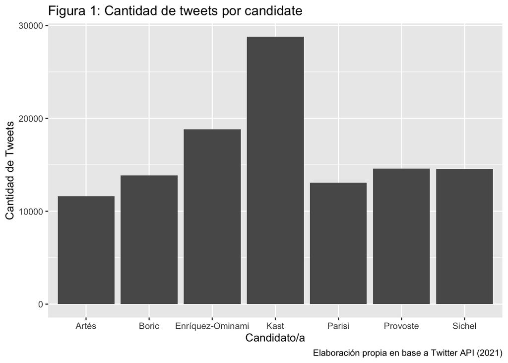

```r
#7.a. Crear df con numero de tweets
n_tweets <- data.frame("Candidates"=c("Boric","Artés","Kast", "Enríquez-Ominami",
                                      "Parisi", "Sichel", "Provoste"),
                        "n_tweets"=c(13863, 11603, 28782, 18829, 13069, 14538, 14586))

#7.b. Crear grafico de barras
ggplot(n_tweets, aes(x= Candidates, y= n_tweets)) +
  geom_bar(stat = "identity") +
  labs(title="Figura 1: Cantidad de tweets por candidate",
  caption="Elaboración propia en base a Twitter API (2021)",
  x="Candidato/a", y="Cantidad de Tweets")
```

```r
#7.c. Promedio
x_tweets <- (13863 + 11603 + 28782 + 18829 + 13069 + 14538 + 14586)/7
```

```r
#8. Eliminar algunos carácteres que tienen los tweets
limpiar_tokenizar <- function(text){
  # Todo el texto a minúsculas
  nuevo_texto <- tolower(text)
  # Eliminación de páginas web y de cualquier cosa que no sea un espacio
  nuevo_texto <- str_replace_all(nuevo_texto,"http\\S*", "")
  # Eliminación de signos de puntuación
  nuevo_texto <- str_replace_all(nuevo_texto,"[[:punct:]]", " ")
  # Eliminación de números
  nuevo_texto <- str_replace_all(nuevo_texto,"[[:digit:]]", " ")
  # Eliminación de espacios en blanco múltiples
  nuevo_texto <- str_replace_all(nuevo_texto,"[\\s]+", " ")
  # Tokenización por palabras individuales
  nuevo_texto <- str_split(nuevo_texto, " ")[[1]]
  # Eliminación de tokens con una longitud < 2
  nuevo_texto <- keep(.x = nuevo_texto, .p = function(x){str_length(x) > 1})
  return(nuevo_texto)
}
```

```r
#9.a. Tokenizar texto Boric
databoric <- databoric %>% mutate(texto_tokenizado = map(.x=databoric$text,
                                                    .f=limpiar_tokenizar))
#9.c. Tokenizar texto Kast
datakast <- datakast %>% mutate(texto_tokenizado = map(.x=datakast$text,
                                                    .f=limpiar_tokenizar))
#9.c. Tokenizar texto Provoste
dataprovoste <- dataprovoste %>% mutate(texto_tokenizado = map(.x=dataprovoste$text,
                                                   .f=limpiar_tokenizar))
#9.d. Tokenizar texto Sichel
datasichel <- datasichel %>% mutate(texto_tokenizado = map(.x=datasichel$text,
                                                    .f=limpiar_tokenizar))
#9.e. Tokenizar texto Enríquez-Ominami
datameo <- datameo %>% mutate(texto_tokenizado = map(.x=datameo$text,
                                                    .f=limpiar_tokenizar))
#9.f. Tokenizar texto Parisi
dataparisi <- dataparisi %>% mutate(texto_tokenizado = map(.x=dataparisi$text,
                                                    .f=limpiar_tokenizar))
#9.g. Tokenizar texto Artés
dataartes <- dataartes %>% mutate(texto_tokenizado = map(.x=dataartes$text,
                                                    .f=limpiar_tokenizar))
```

```r
#10.a. Expansión de la lista de tokens Boric
texto_boric_tidy <- databoric %>% select(texto_tokenizado) %>% unnest(cols=c(texto_tokenizado))
texto_boric_tidy <- texto_boric_tidy %>% rename(token = texto_tokenizado)
head(texto_boric_tidy)
```

```
## # A tibble: 6 × 1
##   token
##   <chr>
## 1 tere
## 2 marinovic
## 3 gabrielboric
## 4 que
## 5 se
## 6 mejore
```

```r
#10.b. Expansión de la lista de tokens Kast
texto_kast_tidy <- datakast %>% select(texto_tokenizado) %>% unnest(cols=c(texto_tokenizado))
texto_kast_tidy <- texto_kast_tidy %>% rename(token = texto_tokenizado)
head(texto_kast_tidy)
```

```
## # A tibble: 6 × 1
##   token
##   <chr>
## 1 encuenta
## 2 virtual
## 3 si
## 4 las
## 5 elecciones
## 6 fueran
```

```r
#10.c. Expansión de la lista de tokens Provoste
texto_provoste_tidy <- dataprovoste %>% select(texto_tokenizado) %>% unnest(cols=c(texto_tokenizado))
texto_provoste_tidy <- texto_provoste_tidy %>% rename(token = texto_tokenizado)
head(texto_provoste_tidy)
```

```
## # A tibble: 6 × 1
##   token
##   <chr>
## 1 gosanchezgh
## 2 lyagonzalez
## 3 provosteyasna
## 4 gabrielboric
## 5 vstromdreire
## 6 provosteyasna
```

```r
#10.d. Expansión de la lista de tokens Sichel
texto_sichel_tidy <- datasichel %>% select(texto_tokenizado) %>% unnest(cols=c(texto_tokenizado))
texto_sichel_tidy <- texto_sichel_tidy %>% rename(token = texto_tokenizado)
head(texto_sichel_tidy)
```

```
## # A tibble: 6 × 1
##   token
##   <chr>
## 1 no
## 2 voto
## 3 por
## 4 sebastiansichel
## 5 pero
## 6 este
```

```r
#10.e. Expansión de la lista de tokens Enríquez-Ominami
texto_meo_tidy <- datameo %>% select(texto_tokenizado) %>% unnest(cols=c(texto_tokenizado))
texto_meo_tidy <- texto_meo_tidy %>% rename(token = texto_tokenizado)
head(texto_meo_tidy)
```

```
## # A tibble: 6 × 1
##   token
##   <chr>
## 1 tercer
## 2 debate
## 3 que
## 4 kast
## 5 se
## 6 ausenta
```

```r
#10.f. Expansión de la lista de tokens Parisi
texto_parisi_tidy <- dataparisi %>% select(texto_tokenizado) %>% unnest(cols=c(texto_tokenizado))
texto_parisi_tidy <- texto_parisi_tidy %>% rename(token = texto_tokenizado)
head(texto_parisi_tidy)
```

```
## # A tibble: 6 × 1
##   token
##   <chr>
## 1 sometiéndome
## 2 al
## 3 pcr
## 4 de
## 5 rigor
## 6 ojalá
```

```r
#10.g. Expansión de la lista de tokens Artés
texto_artes_tidy <- dataartes %>% select(texto_tokenizado) %>% unnest(cols=c(texto_tokenizado))
texto_artes_tidy <- texto_artes_tidy %>% rename(token = texto_tokenizado)
head(texto_artes_tidy)
```

```
## # A tibble: 6 × 1
##   token
##   <chr>
## 1 luissepulvedagl
## 2 el
## 3 ciudadano
## 4 artes
## 5 oficial
## 6 qué
```

```r
#11. Se usa el paquete de pablabras a eliminar en español
lista_stopwords <- stopwords('es')

#12. Se generan las listas de stopwords por candidato
lista_stopwordsboric <- c(lista_stopwords, "de", "que", "los", "se", "con", "no","si",
                                   "gabriel","boric",
                                   "gabrielboric","rt","and",
                                    "dm","san","cta","cl","mr","ht","bco","tan",
                                    "hrs","tantas","vez","y")

lista_stopwordskast <- c(lista_stopwords, "de", "que", "los", "se", "con", "no","si",
                                   "josé", "antonio", "kast", "jak",
                                   "joseantoniokast","rt","and",
                                    "dm","san","cta","cl","mr","ht","bco","tan",
                                    "hrs","tantas","vez","y")

lista_stopwordsprovoste<- c(lista_stopwords, "de", "que", "los", "se", "con", "no","si",
                                   "provoste", "provosteyasna",
                                   "yasna","rt","and",
                                    "dm","san","cl","mr","ht","tan",
                                    "hrs","tantas","vez","y")

lista_stopwordssichel<- c(lista_stopwords, "de", "que", "los", "se", "con", "no","si",
                                   "sichel", "sebastiansichel",
                                   "sebastian","rt","and",
                                    "dm","san","cl","mr","ht","tan",
                                    "hrs","tantas","vez","y")

lista_stopwordsmeo<- c(lista_stopwords, "de", "que", "los", "se", "con", "no","si",
                                   "meo","me-o","marcoenriqueominami",
                                   "marcoporchile","rt","and",
                                    "dm","san","cta","cl","mr","ht","bco","tan",
                                    "hrs","tantas","vez","y")

lista_stopwordsparisi<- c(lista_stopwords, "de", "que", "los", "se", "con", "no","si",
                          "parisi","francoparisi","franco","parisioficial",
                          "oficial","rt","and", "dm","san","cta","cl","mr","ht",
                          "bco","tan", "hrs","tantas","vez","y")

lista_stopwordsartes <- c(lista_stopwords, "de", "que", "los", "se", "con", "no","si",
                                   "eduardo","artes", "artés", "oficial",
                                   "eduardoartes","rt","and",
                                    "dm","san","cl","mr","ht","tan",
                                    "hrs","tantas","vez","y")

#13. Filtrar stopwords
boric_filtered <- texto_boric_tidy %>% filter(!(token %in% lista_stopwordsboric))
kast_filtered <- texto_kast_tidy %>% filter(!(token %in% lista_stopwordskast))
provoste_filtered <- texto_provoste_tidy %>% filter(!(token %in% lista_stopwordsprovoste))
sichel_filtered <- texto_sichel_tidy %>% filter(!(token %in% lista_stopwordssichel))
meo_filtered <- texto_meo_tidy %>% filter(!(token %in% lista_stopwordsmeo))
parisi_filtered <- texto_parisi_tidy %>% filter(!(token %in% lista_stopwordsparisi))
artes_filtered <- texto_artes_tidy %>% filter(!(token %in% lista_stopwordsartes))
```

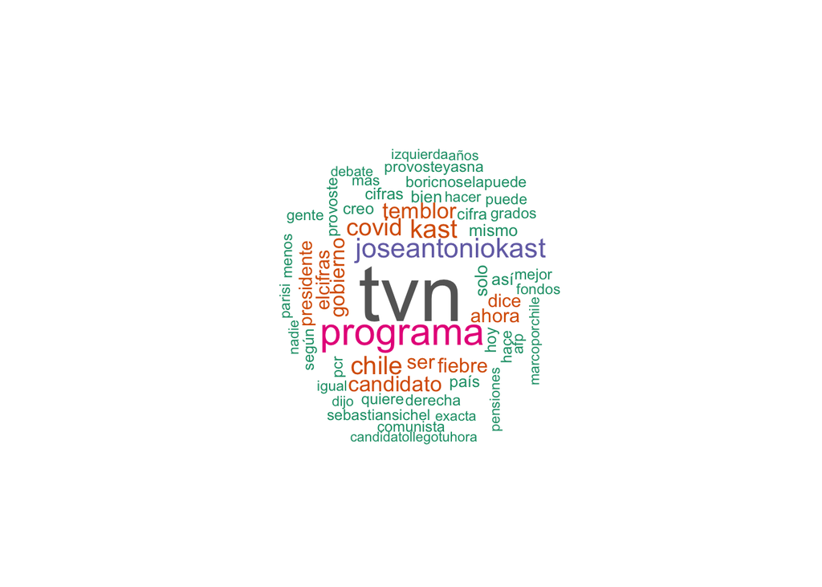

```r
wordcloud(words = boric_filtered$token,
          max.words= 200, min.freq = 200,
          random.order=FALSE, rot.per = 0.35, colors = brewer.pal(8, "Dark2"))
```

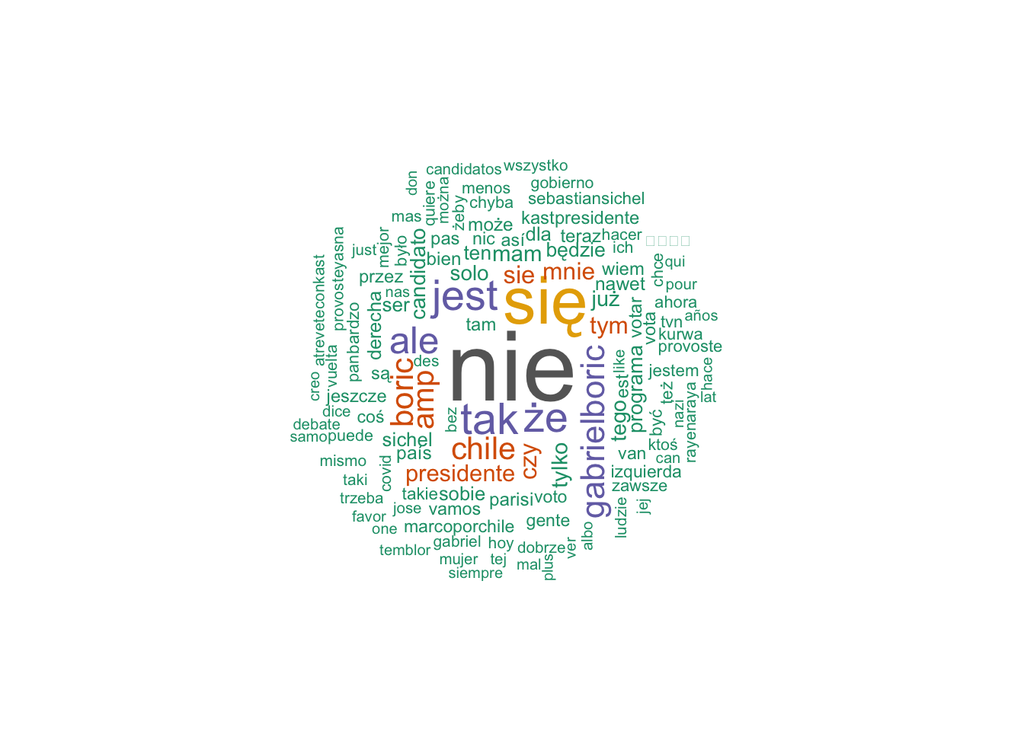

```r
wordcloud(words = kast_filtered$token,
          max.words= 200, min.freq = 200,
          random.order=FALSE, rot.per = 0.35, colors = brewer.pal(8, "Dark2"))
```

Problemas con el identificador “JAK”. Si bien hay tweets que hacen referencia al candidato de esa forma, es una palabra que dificulta el acceso a contenido que realmente haga referencia a J.A.Kast.

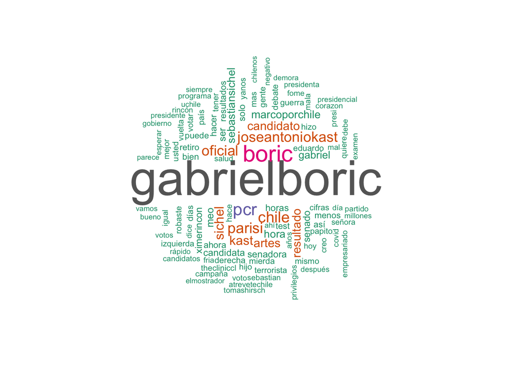

```r
wordcloud(words = provoste_filtered$token,
          max.words= 200, min.freq = 200,
          random.order=FALSE, rot.per = 0.35, colors = brewer.pal(8, "Dark2"))
```

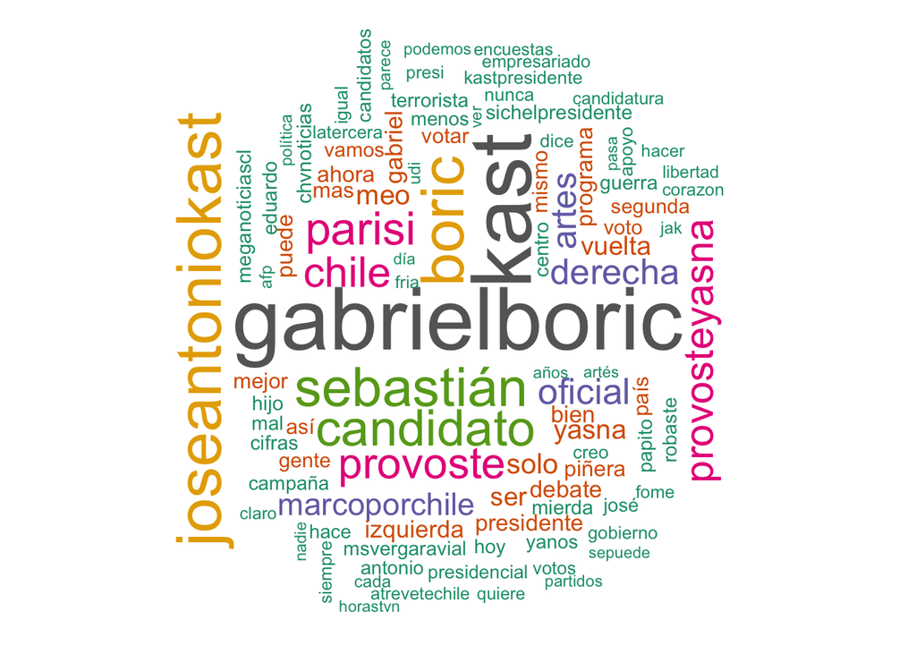

```r
wordcloud(words = sichel_filtered$token,
          max.words= 200, min.freq = 200,
          random.order=FALSE, rot.per = 0.35, colors = brewer.pal(8, "Dark2"))
```

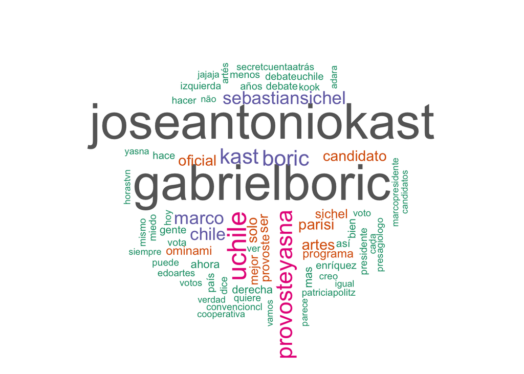

```r
wordcloud(words = meo_filtered$token,
          max.words= 200, min.freq = 200,
          random.order=FALSE, rot.per = 0.35, colors = brewer.pal(8, "Dark2"))
```

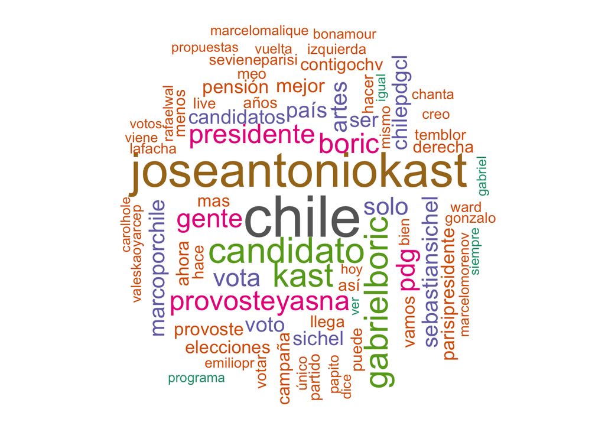

```r
wordcloud(words = parisi_filtered$token,
          max.words= 200, min.freq = 200,
          random.order=FALSE, rot.per = 0.35, colors = brewer.pal(8, "Dark2"))
```

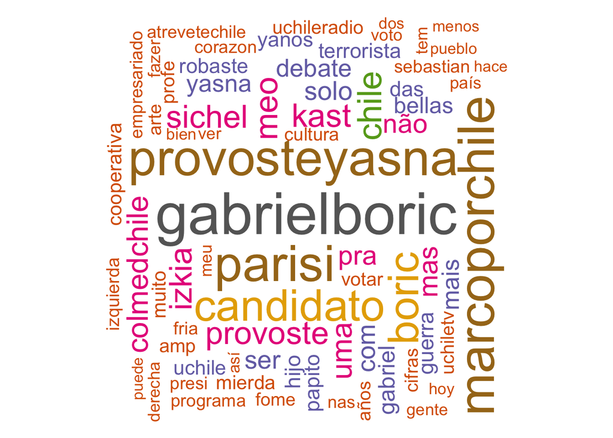

```r
wordcloud(words = artes_filtered$token,
          max.words= 200, min.freq = 200,
          random.order=FALSE, rot.per = 0.35, colors = brewer.pal(8, "Dark2"))
```

.

# 4 Referencias

Barría, G. (2021). Minería de datos web. In F. Urdinez & A. Cruz-Labrín (Eds.), *AnalizaR Datos Políticos* (1st ed.). https://arcruz0.github.io/libroadp/web-mining.html

Bor, S. E. (2014). Using Social Network Sites to Improve Communication Between Political Campaigns and Citizens in the 2012 Election. *American Behavioral Scientist*, *58*(9), 1195–1213. https://doi.org/10.1177/0002764213490698

Calvo, E. (2015). *ANATOMÍA POLÍTICA DE TWITTER EN ARGENTINA*.

Cañete, J., Chaperon, G., Fuentes, R., Ho, J.-H., Kang, H., & Pérez, J. (2020). Spanish Pre-Trained BERT Model and Evaluation Data. *PML4DC at ICLR 2020*.

Dodds, P. S., Harris, K. D., Kloumann, I. M., Bliss, C. A., & Danforth, C. M. (2011). Temporal Patterns of Happiness and Information in a Global Social Network: Hedonometrics and Twitter. *PLoS ONE*, *6*(12), e26752. https://doi.org/10.1371/journal.pone.0026752

Golder, S. A., & Macy, M. W. (2014). Digital Footprints: Opportunities and Challenges for Online Social Research. *Annual Review of Sociology*, *40*(1), 129–152. https://doi.org/10.1146/annurev-soc-071913-043145

González-Bustamante, B., & Muñoz, G. (2012). Campañas digitales: ¿Branding o participación política? El rol de las redes sociales en la última campaña presidencial chilena. *Más Poder Local*, 32–39.

Pang, B., & Lee, L. (2008). Opinion Mining and Sentiment Analysis. *Foundations and Trends® in Information Retrieval*, *2*(1–2), 1–135. https://doi.org/10.1561/1500000011

Steinert-Threlkeld, Z. (2018). Twitter as Data. In M. Alvarez & N. Beck (Eds.), *Elements in Quantitative and Computational Methods for the Social Sciences* (1st ed.). Cambridge University Press. http://mattbarreto.com/mbarreto/courses/Twitter_as_data_ZST.PDF

Tang, D. (2013). Using the R twitteR package. *Https://Davetang.org/Muse/2013/04/06/Using-the-R_twitter-Package/*.

Tironi, A., Cavallo. (2007). *Comunicacion estrategica : Vivir en un mundo de señales.* Taurus.

Valdez Zepeda, A. (2010). Las campañas electorales en la nueva sociedad de la información y el conocimiento. *Estudios Políticos (México)*, 155–165. http://www.scielo.org.mx/scielo.php?script=sci_arttext&pid=S0185-16162010000200009&nrm=iso